# Human Freedom Index and Suicides Project

Part 3: Information Visualization

Doug Cady

November 21, 2021

R version 4.1.2 “Bird Hippie”

```r
library(readr)  # 1.4.0
library(dplyr)  # 1.0.5
library(tidyr)  # 1.1.3
library(ggplot2) # 3.3.5
library(ggpubr)  # 0.4.0
library(gridExtra) # 2.3
library(grid) # base
library(RColorBrewer) # 1.1-2
source("ggplot_theme.R")
```

```r
joined_no2016 <- read_csv("../output/clean_hfi_suicides_joined_no2016.csv",
                          col_types = "dffddddddddffdddd")
```

```r
# print(summary(joined_no2016))
```

## Does a country’s population size impact freedom?

#### There exists only a weak correlation between population size and human freedom for a country

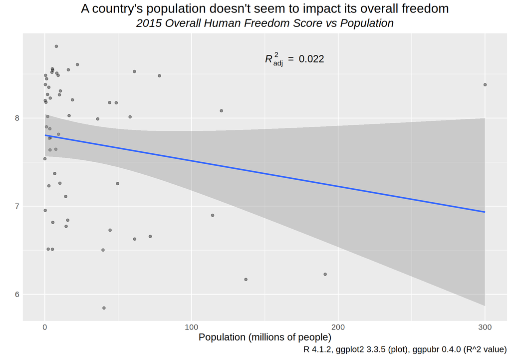

```r
joined_2015 <- filter(joined_no2016, year == 2015) %>%
    group_by(year, country) %>%
    mutate(total_suicides = sum(suicides_no),
           total_pop = sum(population),
           total_suicides_p100k = total_suicides / total_pop * 100000) %>%
    ungroup() %>%
    select(year, country, total_pop, hf_score, total_suicides_p100k, gdp_per_capita) %>%
    unique() %>%
    arrange(total_pop)

ggplot(joined_2015, aes(x = total_pop, y = hf_score)) +
    geom_point(alpha = 0.4) +
    geom_smooth(method = 'lm') +
    stat_regline_equation(aes(label = paste(..adj.rr.label..)), formula = formula,
                          size = 5, label.x.npc = "center", label.y.npc = "top") +
    scale_x_continuous(label = function(x) {paste(x / 1000000)}) +
    labs(x = 'Population (millions of people)', y = '', subtitle = "2015 Overall Human Freedom Score vs Population",
         title = "A country's population doesn't seem to impact its overall freedom",
         caption = "R 4.1.2, ggplot2 3.3.5 (plot), ggpubr 0.4.0 (R^2 value)") +
    theme(text = element_text(size = 14),
          plot.title = element_text(size = 18, hjust = 0.5),
          plot.subtitle = element_text(size = 16, hjust = 0.5, face = 'italic'),
          plot.caption = element_text(size = 12),
          axis.ticks = element_blank())
```

```r
ggsave("../graphics/scat_pop_freedom.png", width = 9, height = 6, units = "in")

# Hypothesis: Countries with smaller populations will have more freedom
total_rows <- nrow(joined_2015)  # 56
row_split <- total_rows / 2  # 28
small_pop <- joined_2015[1:28, ]
large_pop <- joined_2015[29:56, ]

# Perform a Welch's t-test to determine if two populations are signifcantly different
# p-value of 0.06, significant at 90% confidence level, but I am using 95% confidence
# Fail to reject null hypothesis at 95% confidence level, though it's close
t.test(small_pop$hf_score, large_pop$hf_score)
```

```
##
##  Welch Two Sample t-test
##
## data:  small_pop$hf_score and large_pop$hf_score
## t = 1.9, df = 50, p-value = 0.06
## alternative hypothesis: true difference in means is not equal to 0
## 95 percent confidence interval:
##  -0.01253  0.80089
## sample estimates:
## mean of x mean of y
##     7.912     7.518
```

## Do female freedom scores relate to female suicide rates?

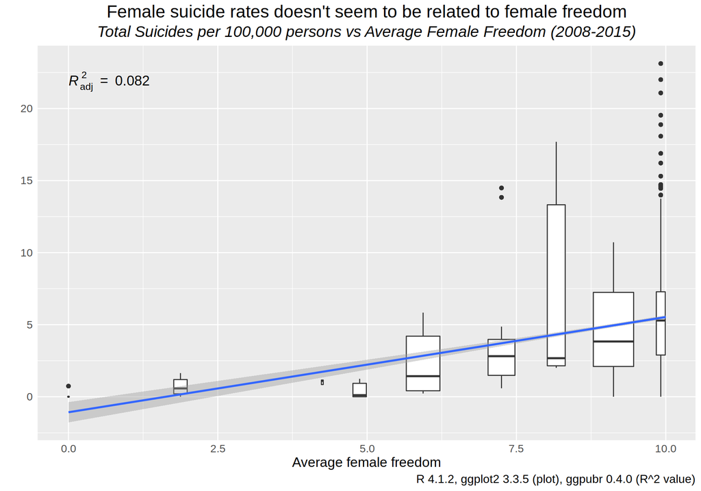

```r
# Aggregate data to remove age, sex breakdowns
fem_freedom_suic <- joined_no2016 %>%
    filter(sex == 'female') %>%
    group_by(year, country) %>%
    mutate(total_suicides = sum(suicides_no),
           total_pop = sum(population),
           total_suicides_p100k = total_suicides / total_pop * 100000) %>%
    ungroup() %>%
    select(year, country, pf_ss_women_fgm, pf_ss_women_inheritance, pf_movement_women,
           pf_identity_sex_female, pf_identity_divorce, total_suicides_p100k)

# Calculate average of 5 female freedom columns across each row
fem_freedom_suic$avg_fem_freedom <- rowMeans(select(fem_freedom_suic,
                                                    pf_ss_women_fgm, pf_ss_women_inheritance,
                                                    pf_movement_women, pf_identity_sex_female,
                                                    pf_identity_divorce), na.rm = TRUE)

# Multiple Boxplots by Freedom bin group
formula <- y ~ x

# More than half of countries have an average female freedom score of 10!
# Their suicide rates cover the whole range from low to high rates, incidating a lack of relationship
ggplot(fem_freedom_suic, aes(x = avg_fem_freedom, y = total_suicides_p100k)) +
    geom_boxplot(aes(group = cut_width(avg_fem_freedom, 1))) +
    geom_smooth(method = 'lm') +
    stat_regline_equation(aes(label = paste(..adj.rr.label..)), formula = formula, size = 5) +
    labs(x = 'Average female freedom', y = '',
         subtitle = "Total Suicides per 100,000 persons vs Average Female Freedom (2008-2015)",
         title = "Female suicide rates doesn't seem to be related to female freedom",
         caption = "R 4.1.2, ggplot2 3.3.5 (plot), ggpubr 0.4.0 (R^2 value)") +
    theme(text = element_text(size = 14),
          plot.title = element_text(size = 18, hjust = 0.5),
          plot.subtitle = element_text(size = 16, hjust = 0.5, face = 'italic'),
          plot.caption = element_text(size = 12),
          axis.ticks = element_blank())
```

```r
ggsave("../graphics/box_fem_suic_free.png", width = 9, height = 6, units = "in")

# Also, I tried geom_jitter, stat_binhex, and stat_bin2d, but the boxplots seemed the best
# at communicating the lack of relationship


# Hypothesis: Countries with high female freedom scores will have less than average female suicide rates
sorted_fem_free_scores <- fem_freedom_suic %>%
    filter(year == 2015) %>%
    unique() %>%
    select(avg_fem_freedom, total_suicides_p100k) %>%
    arrange(desc(avg_fem_freedom))

print(nrow(sorted_fem_free_scores)) # 56 countries
```

```
## [1] 56
```

```r
hi_fem_free <- sorted_fem_free_scores[1:28, ]
lo_fem_free <- sorted_fem_free_scores[29:56, ]
# Perform a Welch's t-test to determine if two populations are signifcantly different
# p-value of 0.01, significant at 98% confidence level
# Reject null hypothesis and conclude that there may exist a relationship between higher suicide rates and freedom
# BUT if we look back at the scatter plot of suicide rates vs freedom scores, more than half
# (almost 65%) of the countries have a freedom score of 10. So which countries should be classified
# as lo vs hi freedom if there are `10` scores in both groups??
t.test(hi_fem_free$total_suicides_p100k, lo_fem_free$total_suicides_p100k)
```

```
##
##  Welch Two Sample t-test
##
## data:  hi_fem_free$total_suicides_p100k and lo_fem_free$total_suicides_p100k
## t = 2.7, df = 49, p-value = 0.01
## alternative hypothesis: true difference in means is not equal to 0
## 95 percent confidence interval:
##  0.5406 3.7646
## sample estimates:
## mean of x mean of y
##     6.326     4.173
```

#### The relationship between female freedom in a country and female suicide rates is non-existent to weak in strength. Many countries have top freedom scores and have a wide range of suicide rates per one hundred thousand persons.

## Juxtaposed row-labeled plots - compare many country’s freedom scores, suicide rates, population, and GDP per capita

```r
# Plotting functions to create and save plots
make_juxta_plot <- function(plot_side, data, x, y, xlab, caption, scale_x) {
    gg_init <- ggplot(data, aes_string(x = x, y = y, group = "prox_grp", color = "color_grp")) +
        geom_path(color = "gray60") +
        geom_point(size = 3.5) +
        geom_point(color = "white", size = 1) +
        facet_grid(prox_grp ~ ., space = "free_y", scales = "free_y") +
        labs(x = xlab, y = '', caption = caption) +
        theme(legend.position = "none") +
        ggplot_clean_theme +
        guides(color = FALSE)

    if (scale_x > 0) {
        gg_inter <-  gg_init + scale_x_continuous(label = function(x) {paste(x / scale_x)},
                                                  expand = expansion(mult = c(0.04, 0.04)))
    } else {
        gg_inter <-  gg_init + scale_x_continuous(expand = expansion(mult = c(0.04, 0.04)))
    }

    if (plot_side == "right") {
        return (gg_inter + theme(axis.text.y = element_blank()))
    } else {
        return (gg_inter)
    }
}

# Combine and then save juxtaposed plots (2 columns)
save_juxta_plot <- function(left, right, title, filename) {
    grid.arrange(left, right, ncol = 2, top = textGrob(title))
    arranged_plots <- arrangeGrob(left, right, ncol = 2, top = textGrob(title))
    ggsave(plot = arranged_plots, filename, width = 9, height = 9, units = "in")
}

caption_pkgs <- "R 4.1.2, ggplot2 3.3.5 (plot), gridExtra 2.3 (arrange plot grid), grid"
```

##### There doesn’t seem to be much of a relationship here. If there was, we would expect freedom to have a positive/negative trend alongside their populations.

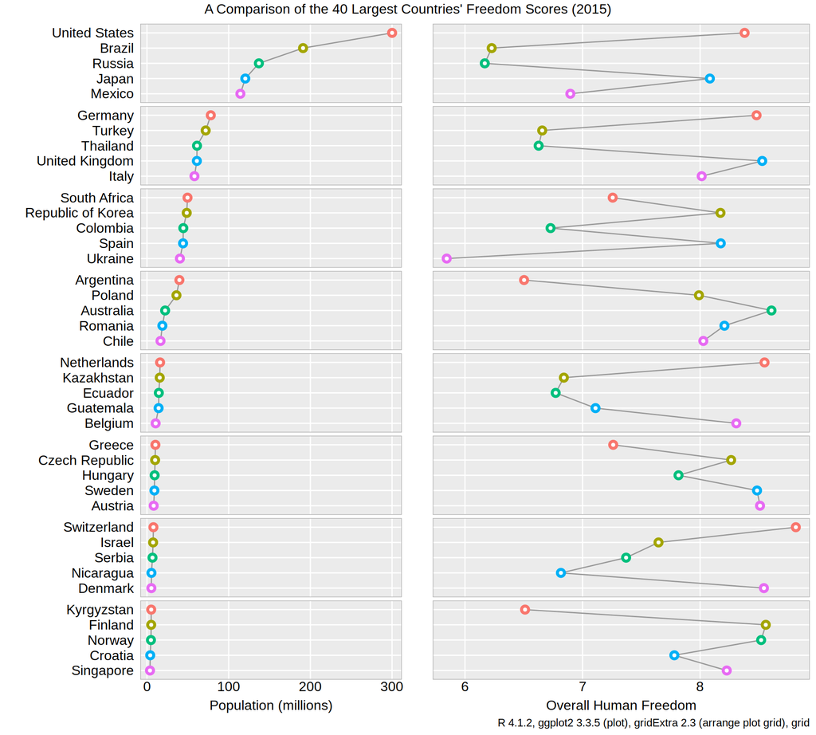

```r
# Population vs Freedom
juxta_data <- joined_2015[17:56, ] %>%
    select(country, total_pop, hf_score, total_suicides_p100k) %>%
    arrange(-total_pop) %>%
    mutate(country = reorder(country, total_pop),
           prox_grp = rep(paste0("G", 1:8), each = 5),
           color_grp = rep(paste0("CG", 1:5), times = 8))

# Add proximity groups of 5 for ease of distinguishing countries
# juxta_data$prox_grp <- rep(paste0("G", 1:5), each = 5)
# juxta_data$color_grp <- rep(c("CG1", "CG2", "CG3", "CG4", "CG5"), times = 5)

gg_left <- make_juxta_plot(plot_side = "left", data = juxta_data, x = "total_pop", y = "country",
                           xlab = "Population (millions)", caption = '', scale_x = 1000000)

gg_right <- make_juxta_plot(plot_side = "right", data = juxta_data, x = "hf_score", y = "country",
                            xlab = "Overall Human Freedom", caption = caption_pkgs, scale_x = 0)

grid_title <- "A Comparison of the 40 Largest Countries' Freedom Scores (2015)"
pop_free_fn <- "../graphics/juxta_row_pop_free.png"
save_juxta_plot(left = gg_left, right = gg_right, title = grid_title, filename = pop_free_fn)
```

## Freedom vs Suicide rate

##### There might be a weak positive relationship here. It shows that higher freedom countries have higher suicide rates. That’s curious.

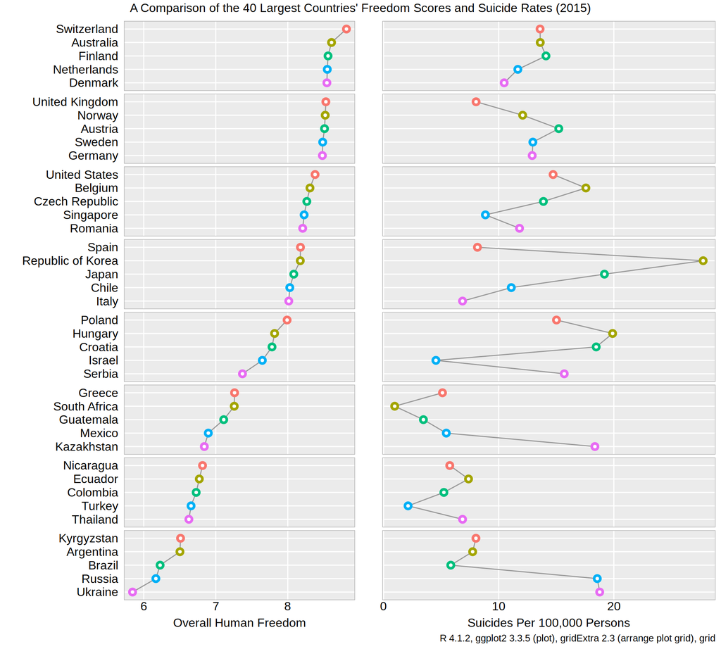

```r
# 40 largest countries
free_suic_juxta_data <- joined_2015[17:56, ] %>%
    select(country, hf_score, total_suicides_p100k) %>%
    droplevels() %>%
    arrange(-hf_score, total_suicides_p100k)

countries_ordered <- rev(unique(free_suic_juxta_data$country))

free_suic_juxta_data <- free_suic_juxta_data %>%
    mutate(country = factor(country, levels = countries_ordered),
           prox_grp = rep(paste0("G", 1:8), each = 5),
           color_grp = rep(paste0("CG", 1:5), times = 8))

# Freedom vs Suicide Rates
gg_left <- make_juxta_plot(plot_side = "left", data = free_suic_juxta_data,
                           x = "hf_score", y = "country",
                           xlab = "Overall Human Freedom", caption = '', scale_x = 0)

gg_right <- make_juxta_plot(plot_side = "right", data = free_suic_juxta_data,
                            x = "total_suicides_p100k", y = "country",
                            xlab = "Suicides Per 100,000 Persons", caption = caption_pkgs,
                            scale_x = 0)

grid_title <- "A Comparison of the 40 Largest Countries' Freedom Scores and Suicide Rates (2015)"
free_suic_fn <- "../graphics/juxta_row_free_suic.png"
save_juxta_plot(left = gg_left, right = gg_right, title = grid_title, filename = free_suic_fn)
```

## GDP per Capita vs Freedom

##### There seems to be a fairly strong positive relationship between a country’s GDP per capita and its human freedom score. It may be easier for wealthy countries to be democratic and enjoy greater freedom. Future work: this may be related to how long a state has been independent and whether it was an imperial power or previous colony (what side of the spectrum in extracting resources and wealth).

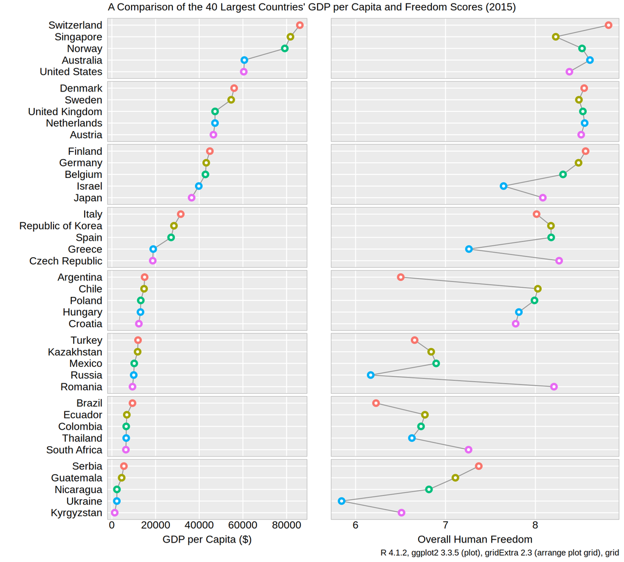

```r
gdp_free_juxta_data <- joined_2015[17:56, ] %>%
    select(country, hf_score, gdp_per_capita) %>%
    droplevels() %>%
    arrange(-gdp_per_capita)

countries_ordered <- rev(unique(gdp_free_juxta_data$country))

gdp_free_juxta_data <- gdp_free_juxta_data %>%
    mutate(country = factor(country, levels = countries_ordered),
           prox_grp = rep(paste0("G", 1:8), each = 5),
           color_grp = rep(paste0("CG", 1:5), times = 8))

# GDP per Capita vs Freedom
gg_left <- make_juxta_plot(plot_side = "left", data = gdp_free_juxta_data,
                           x = "gdp_per_capita", y = "country",
                           xlab = "GDP per Capita ($)", caption = '', scale_x = 0)

gg_right <- make_juxta_plot(plot_side = "right", data = gdp_free_juxta_data,
                            x = "hf_score", y = "country",
                            xlab = "Overall Human Freedom", caption = caption_pkgs, scale_x = 0)

grid_title <- "A Comparison of the 40 Largest Countries' GDP per Capita and Freedom Scores (2015)"
gdp_free_fn <- "../graphics/juxta_row_gdp_free.png"
save_juxta_plot(left = gg_left, right = gg_right, title = grid_title, filename = gdp_free_fn)
```

## Time-series Analysis

##### Median scores are higher for the 2 subcategories of freedom - personal and economic - and the overall score as well. Most country’s Personal freedom scores are higher than their overall or economic scores with economic scores generally being the lowest.

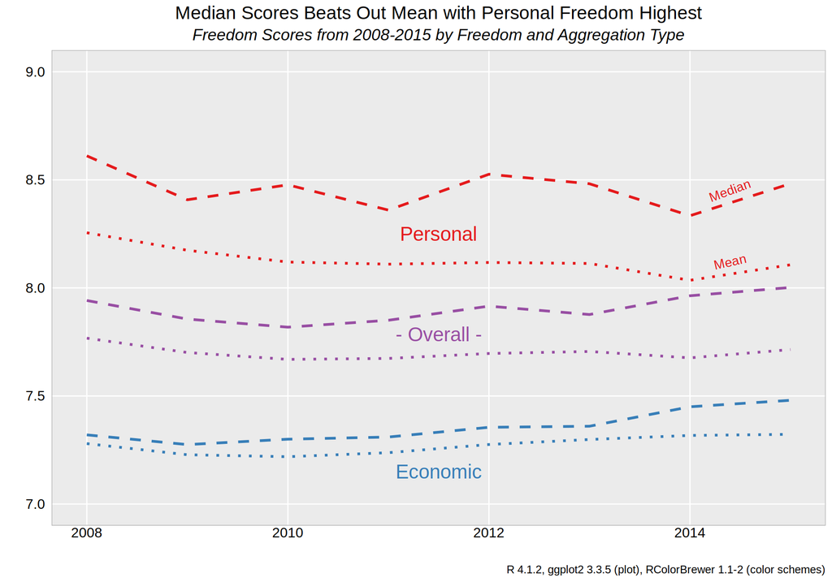

```r
score_cols <- c("pf_score", "ef_score", "hf_score")

scores <- joined_no2016 %>%
    pivot_longer(cols = score_cols, names_to = "freedom", values_to = "score") %>%
    select(year, freedom, score)

scores$freedom <- recode_factor(scores$freedom, "pf_score" = "Personal",
                                                "hf_score" = "- Overall -",
                                                "ef_score" = "Economic")
freedom_aggs <- scores %>%
    group_by(year, freedom) %>%
    summarize(Median = median(score, na.rm = TRUE),
              Mean = mean(score, na.rm = TRUE)) %>%
    pivot_longer(cols = c("Median", "Mean"), names_to = "agg_type", values_to = "value") %>%
    mutate(free_agg_comb = paste0(freedom, "_", agg_type))

# freedom_aggs

agg_type_linetypes <- c("Median" = "dashed", "Mean" = "dotted")
freedom_colors <- c("Personal" = "#E41A1C", "- Overall -" = "#984EA3", "Economic" = "#377EB8")

gg_freedom_agg <- freedom_aggs %>%
    ggplot(aes(x = year, y = value, group = free_agg_comb, color = freedom)) +
    geom_line(aes(linetype = agg_type), size = 1.1) +
    labs(x = '', y = '', title = "Median Scores Beats Out Mean with Personal Freedom Highest",
         subtitle = "Freedom Scores from 2008-2015 by Freedom and Aggregation Type",
         caption = "R 4.1.2, ggplot2 3.3.5 (plot), RColorBrewer 1.1-2 (color schemes)") +
    scale_linetype_manual(values = agg_type_linetypes, guide = "none") +
    scale_color_manual(values = freedom_colors, guide = "none") +
    scale_y_continuous(limits = c(7, 9)) +
    ggplot_clean_theme +
    # 3 Freedom type labels
    annotate(geom = "text", x = 2011.5, y = 8.25, label = "Personal",
             color = freedom_colors[["Personal"]], size = 6) +
    annotate(geom = "text", x = 2011.5, y = 7.785, label = "- Overall -",
             color = freedom_colors[["- Overall -"]], size = 6) +
    annotate(geom = "text", x = 2011.5, y = 7.15, label = "Economic",
             color = freedom_colors[["Economic"]], size = 6) +
    # Aggregation Type labels
    annotate(geom = "text", x = 2014.4, y = 8.45, label = "Median",
             color = freedom_colors[["Personal"]], size = 4, angle = 20) +
    annotate(geom = "text", x = 2014.4, y = 8.12, label = "Mean",
             color = freedom_colors[["Personal"]], size = 4, angle = 13)

ggsave(plot = gg_freedom_agg, "../graphics/time_freedom_agg.png",
       width = 10, height = 7, units = "in")

gg_freedom_agg
```